# Quick start

Jorge Cabral

[figure not shown]

## Introduction

In this vignette, the theoretical considerations are skipped and simple examples of several `GCEstim` functions are given.

## lmgce()

Consider `dataThesis` (see “Generalized Maximum Entropy framework”).

```
#>       X001                X002               X003                X004
#>  Min.   :-0.632481   Min.   :-0.33234   Min.   :-0.176809   Min.   :-0.22971
#>  1st Qu.:-0.106850   1st Qu.:-0.07391   1st Qu.:-0.056879   1st Qu.:-0.08982
#>  Median :-0.003362   Median :-0.01655   Median :-0.004816   Median :-0.01277
#>  Mean   : 0.016769   Mean   :-0.01209   Mean   :-0.007288   Mean   :-0.01441
#>  3rd Qu.: 0.128388   3rd Qu.: 0.06120   3rd Qu.: 0.043791   3rd Qu.: 0.06338
#>  Max.   : 0.494303   Max.   : 0.23579   Max.   : 0.131458   Max.   : 0.19744
#>        y
#>  Min.   :-11.196
#>  1st Qu.: -5.017
#>  Median : -3.595
#>  Mean   : -3.702
#>  3rd Qu.: -2.225
#>  Max.   :  1.780
```

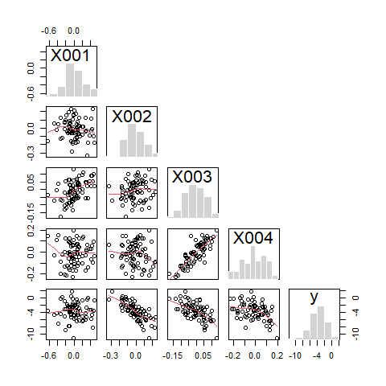

Suppose we want to obtain the estimates for the model

$$\begin{equation}
\mathbf{y}=\beta_0\mathbf{1}_N + \beta_1\mathbf{X001} +
\beta_2\mathbf{X002} + \beta_3\mathbf{X003} + \beta_4\mathbf{X004}.
\end{equation}$$

Using the function `lmgce()` and setting:

- `formula = y ~ X001 + X002 + X003 + X004`
- `data = dataThesis`

the desired model is computed in a Two-stage Adaptive Standardized-coefficients-informed Weighted Generalized Cross Entropy (TASW-GCE) Framework. In particular, with 5 points for the signal support space, 3 points for the noise support space, a weight of 0.5 and uniform priors for both signal and support (`help("lmgce")`).

```r
res.lmgce.v01 <-
  lmgce(
    formula = y ~ X001 + X002 + X003 + X004,
    data = dataThesis)
```

If we would like to see a concise summary of the result we can simply type,

```r
res.lmgce.v01
```

```
#>
#> Call:
#> lmgce(formula = y ~ X001 + X002 + X003 + X004, data = dataThesis)
#>
#> Coefficients:
#> (Intercept)         X001         X002         X003         X004
#>     -3.6957       0.4688     -11.6308     -11.4579      -4.0745
```

To obtain a more detailed evaluation of the fitted model, we can use `summary()`

```r
summary(res.lmgce.v01)
```

```
#>
#> Call:
#> lmgce(formula = y ~ X001 + X002 + X003 + X004, data = dataThesis)
#>
#> Residuals:
#>     Min      1Q  Median      3Q     Max
#> -3.3538 -0.8861 -0.1564  0.3509  1.8425
#>
#> Coefficients:
#>               Estimate Std. Deviation   z value Pr(>|t|)
#> (Intercept) -3.696e+00      6.455e-06 -572528.9   <2e-16 ***
#> X001         4.688e-01      6.787e-04     690.7   <2e-16 ***
#> X002        -1.163e+01      7.944e-04  -14640.3   <2e-16 ***
#> X003        -1.146e+01      4.761e-03   -2406.9   <2e-16 ***
#> X004        -4.074e+00      2.575e-03   -1582.2   <2e-16 ***
#> ---
#> Signif. codes:  0 '***' 0.001 '**' 0.01 '*' 0.05 '.' 0.1 ' ' 1
#>
#> Normalized Entropy:
#>              NormEnt  SupportLL SupportUL
#> (Intercept) 0.422679  -4.311289  4.311289
#> X001        0.998446  -9.377392  9.377392
#> X002        0.730749 -18.577182 18.577182
#> X003        0.922430 -32.878041 32.878041
#> X004        0.976360 -20.975389 20.975389
#>
#> Residual standard error: 1.102 on 70 degrees of freedom
#> Chosen Upper Limit for Standardized Supports: 0.9059, Chosen Error: 1se
#> Multiple R-squared: 0.7364, Adjusted R-squared: 0.7214
#> NormEnt: 0.8101, CV-NormEnt:  0.81 (0.0009853)
#> RMSE: 1.064, CV-RMSE: 1.034 (0.281)
```

The estimated GCE coefficients are $\widehat{\boldsymbol{\beta}}^{TASW\text{-}GCE}=$ (-3.696, 0.469, -11.631, -11.458, -4.074).

```r
(coef.res.lmgce.v01 <- coef(res.lmgce.v01))
```

```
#> (Intercept)        X001        X002        X003        X004
#>  -3.6957113   0.4687837 -11.6307903 -11.4579458  -4.0744707
```

The prediction root mean squared error (RMSE) is $RMSE^{ y, TASW\text{-}GCE} \approx$ 1.064.

```r
res.lmgce.v01$error.measure
```

```
#> [1] 1.064306
```

The prediction 5-fold cross-validation (CV) error is $CV\text{-}RMSE^{y,TASW\text{-}GCE} \approx$ 1.034.

```r
res.lmgce.v01$error.measure.cv.mean
```

```
#> [1] 1.033978
```

Z-score confidence intervals (CIs) are obtained with the `confint` S3 method for class `lmgce`

```r
confint(res.lmgce.v01, level = 0.95)
```

```
#>                    2.5%      97.5%
#> (Intercept)  -3.6957240  -3.695699
#> X001          0.4674534   0.470114
#> X002        -11.6323474 -11.629233
#> X003        -11.4672763 -11.448615
#> X004         -4.0795179  -4.069424
```

and can be visualized with `plot`

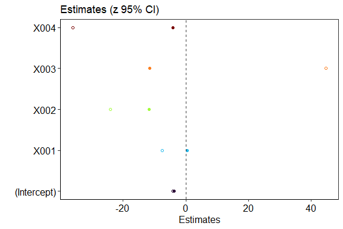

```r
plot(res.lmgce.v01, which = 1)$p1
```

Color-filled dots represent the GCE estimates while non-filled dots represent the OLS estimates (`lmgce` uses by default `OLS = TRUE`).

```r
res.lmgce.v01.confint <-
  confint(
    res.lmgce.v01,
    level = 0.95,
    method = "basic",
    boot.B = 100,
    boot.method = "residuals"
  )
```

```r
res.lmgce.v01.confint
```

```
#>                     2.5%      97.5%
#> (Intercept)  -3.85996624  -3.552136
#> X001          0.07113198   1.331706
#> X002        -15.17611611 -12.038166
#> X003        -14.34763341 -11.293882
#> X004         -5.89776869  -3.157915
```

or

```r
res.lmgce.v02 <-
  update(res.lmgce.v01,
         boot.B = 100,
         boot.method = "residuals")
res.lmgce.v02.confint <-
  confint(
    res.lmgce.v02,
    level = 0.95,
    method = "basic"
  )
```

```r
res.lmgce.v02.confint
```

```
#>                     2.5%      97.5%
#> (Intercept)  -3.85996624  -3.552136
#> X001          0.07113198   1.331706
#> X002        -15.17611611 -12.038166
#> X003        -14.34763341 -11.293882
#> X004         -5.89776869  -3.157915
```

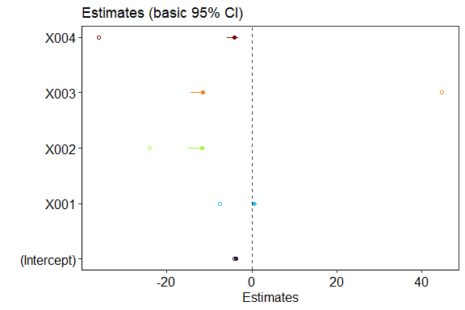

```r
plot(res.lmgce.v02, which = 1, ci.method = "basic")$p1
```

From the previous summary we can see that the standardized parameter chosen was 0.9059

```r
res.lmgce.v01$support.stdUL
```

```
#> [1] 0.9059
```

and corresponds to the support spaces which cross-validation RMSE (CV-RMSE) is not greater than the minimum CV-RMSE plus one standard error (1se)

```r
res.lmgce.v01$support.signal.1se
```

```
#> [1] 0.9059
```

During estimation, standardized limits are reverted to the original scale

```r
res.lmgce.v01$support.matrix #original scale
```

```
#>              SupportLL SupportUL
#> (Intercept)  -4.311289  4.311289
#> X001         -9.377392  9.377392
#> X002        -18.577182 18.577182
#> X003        -32.878041 32.878041
#> X004        -20.975389 20.975389
```

`lmgce` uses by default `support.signal = NULL` and `support.signal.vector = NULL` meaning that it will evaluate the `errormeasure = "RMSE"` with cross-validation (`cv = TRUE`, `cv.nfolds = 5`) in a set of `support.signal.vector.n = 20` supports spaces logarithmically between `support.signal.vector.min = 0.3` and `support.signal.vector.min = 20`. It will then choose the minimum, one standard error or elbow error (see `help("lmgce")`).

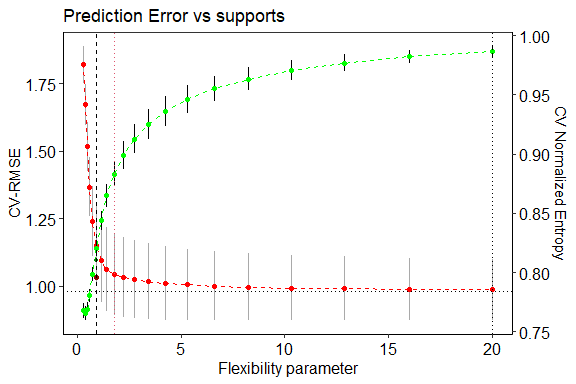

```r
plot(res.lmgce.v01, which = 2)$p2
```

Red dots represent the CV-error and green dots the CV-Normalized entropy. Whiskers have the length of two standard errors of the CV mean for each of the 20 support spaces tested. The dotted horizontal line is the OLS CV-error. The black vertical dotted line corresponds to the support spaces that produced the lowest CV-error. The black vertical dashed line corresponds to the support spaces that produced the 1se CV-error. The red vertical dotted line corresponds to the support spaces that produced the elbow CV-error.

With `plot` it is possible to obtain the trace of the estimates

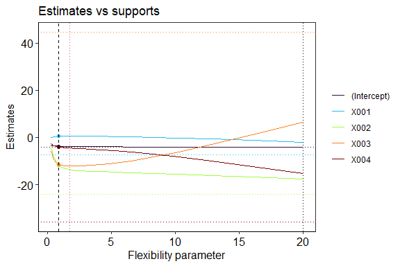

```r
plot(res.lmgce.v01, which = 3)$p3
```

In the last two plots are depicted the final solutions. That is to say that after choosing the support spaces limits based on the defined error, the number of points of the support spaces and their probability `support.signal.points = c(1/5, 1/5, 1/5, 1/5, 1/5)` and `support.signal.points = c(1/3, 1/3, 1/3)`, `twosteps.n = 1` extra estimation(s) is(are) performed. This estimation uses the GCE framework even if the previous steps were by default on the GME framework. The distribution of probabilities used is the one estimated for the chosen support spaces.

```r
res.lmgce.v01$p0
```

```
#>                   p_1       p_2        p_3        p_4        p_5
#> (Intercept) 0.7765862 0.1738391 0.03891393 0.00871090 0.00194994
#> X001        0.1805333 0.1897807 0.19950181 0.20972083 0.22046329
#> X002        0.5508961 0.2536953 0.11683017 0.05380191 0.02477652
#> X003        0.3663295 0.2533743 0.17524802 0.12121147 0.08383673
#> X004        0.2856466 0.2344356 0.19240585 0.15791119 0.12960076
```

```r
res.lmgce.v01$w0[1:5, ] # for the first 5 lines
```

```
#>         p_1       p_2       p_3
#> 1 0.2672761 0.3286375 0.4040863
#> 2 0.3305380 0.3333255 0.3361365
#> 3 0.2975938 0.3320069 0.3703994
#> 4 0.4073613 0.3282064 0.2644323
#> 5 0.3513099 0.3330158 0.3156743
```

The trace of the CV-error with the reestimations can be obtained with `plot`

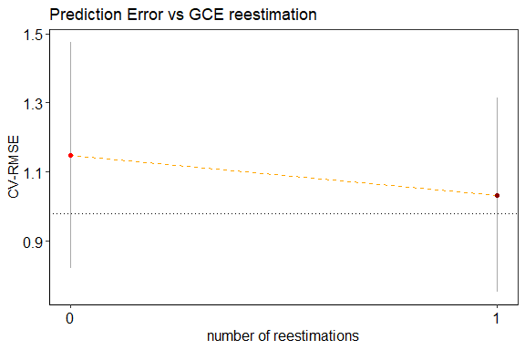

```r
plot(res.lmgce.v01, which = 6)$p6
```

The pre reestimation CV-error is depicted by the red dot and final/reestimated CV-error corresponds to the dark red dot. The horizontal dotted line represents again the OLS CV-error. The final estimated vectors of probabilities is

```r
res.lmgce.v01$p
```

```
#>                   p_1       p_2        p_3        p_4        p_5
#> (Intercept) 0.7766072 0.1738273 0.03890761 0.00870866 0.00194925
#> X001        0.1804988 0.1897617 0.19950000 0.20973803 0.22050147
#> X002        0.5509065 0.2536937 0.11682650 0.05379887 0.02477450
#> X003        0.3662867 0.2533674 0.17525898 0.12122992 0.08385701
#> X004        0.2856185 0.2344269 0.19241041 0.15792455 0.12961962
```

```r
res.lmgce.v01$w[1:5, ]
```

```
#>         p_1       p_2       p_3
#> 1 0.2672858 0.3286390 0.4040752
#> 2 0.3305303 0.3333255 0.3361442
#> 3 0.2975896 0.3320065 0.3704039
#> 4 0.4073550 0.3282073 0.2644377
#> 5 0.3513128 0.3330157 0.3156716
```

After looking at the results and traces we may feel the need to select a different support, lets say the minimum. That can obviously be done using, for instance

```r
lmgce(y ~ X001 + X002 + X003 + X004,
      data = dataThesis,
      errormeasure.which = "min")
#or
update(res.lmgce.v01, errormeasure.which = "min")
```

but that implies a complete reestimation and can be very time-costly. Since the results of all the evaluated support spaces are stored, choosing a different support should be done with `changesupport`

```r
res.lmgce.v01.min <- changesupport(res.lmgce.v01, "min")
```

```r
summary(res.lmgce.v01.min)
```

```
#>
#> Call:
#> lmgce(formula = y ~ X001 + X002 + X003 + X004, data = dataThesis)
#>
#> Residuals:
#>     Min      1Q  Median      3Q     Max
#> -2.6246 -0.5646  0.1015  0.5219  2.0774
#>
#> Coefficients:
#>               Estimate Std. Deviation   z value Pr(>|t|)
#> (Intercept) -4.045e+00      1.397e-05 -289577.5   <2e-16 ***
#> X001        -2.022e+00      1.469e-03   -1376.7   <2e-16 ***
#> X002        -1.773e+01      1.719e-03  -10313.2   <2e-16 ***
#> X003         6.359e+00      1.030e-02     617.3   <2e-16 ***
#> X004        -1.518e+01      5.573e-03   -2724.2   <2e-16 ***
#> ---
#> Signif. codes:  0 '***' 0.001 '**' 0.01 '*' 0.05 '.' 0.1 ' ' 1
#>
#> Normalized Entropy:
#>              NormEnt  SupportLL SupportUL
#> (Intercept) 0.964998  -17.14915  17.14915
#> X001        0.999941 -207.02929 207.02929
#> X002        0.998838 -410.13759 410.13759
#> X003        0.999952 -725.86468 725.86468
#> X004        0.999332 -463.08398 463.08398
#>
#> Residual standard error: 0.9815 on 70 degrees of freedom
#> Chosen Upper Limit for Standardized Supports: 20, Chosen Error: min
#> Multiple R-squared: 0.8361, Adjusted R-squared: 0.8267
#> NormEnt: 0.9926, CV-NormEnt: 0.9926 (4.881e-06)
#> RMSE: 0.9483, CV-RMSE: 0.9242 (0.2376)
```

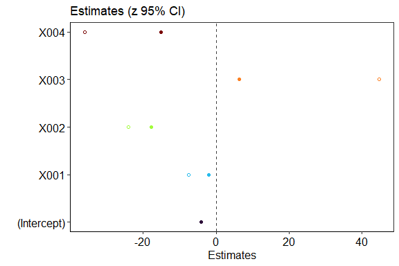

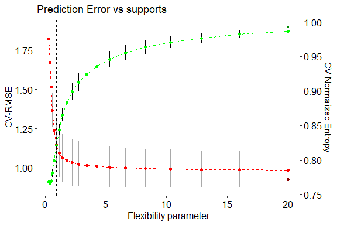

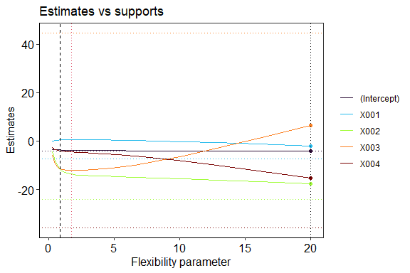

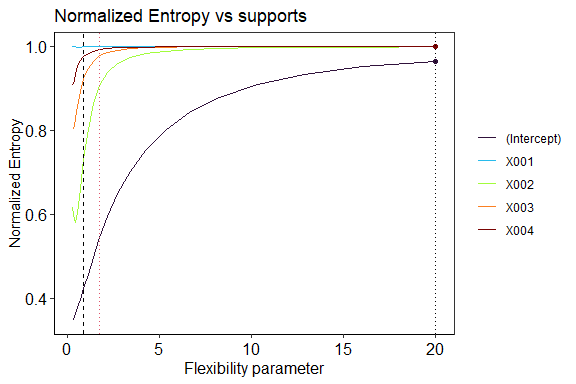

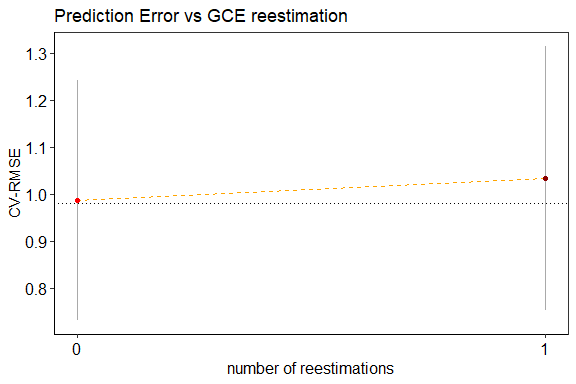

```r
plot(res.lmgce.v01.min)
```

Note that the GCE estimates are now “closer” to the OLS estimates.  
In this example the true coefficients are known and we can also observe that the `1se` approach gives estimates “closer” to those coefficients.

```r
data.frame("Supp_1se" = coef(res.lmgce.v01),
           "Supp_min" = coef(res.lmgce.v01.min),
           "OLS" = coef(res.lmgce.v01$results$OLS$res),
           "TRUE" = coef.dataThesis)
```

```
#>                Supp_1se   Supp_min        OLS TRUE.
#> (Intercept)  -3.6957113  -4.045302  -4.060541    -4
#> X001          0.4687837  -2.022251  -7.470739     0
#> X002        -11.6307903 -17.731222 -24.117970   -16
#> X003        -11.4579458   6.359279  44.677570   -12
#> X004         -4.0744707 -15.181731 -35.934748    -5
```

Several generic functions can used with `lmgce` class objects, for instance

```r
fitted(res.lmgce.v01)[1:5]
```

```
#>         1         2         3         4         5
#> -1.923023 -5.968547 -4.174583 -5.388990 -3.342422
```

```r
predict(res.lmgce.v01, dataGCE[1,])
```

```
#>         1
#> -4.127846
```

## lmgceAddin()

An add-in to easily generate the R code for a `lmgce` analysis and to perform that analysis can be accessed with

```r
lmgceAddin()
```

Data can be imported from a file or be called from the `Environment`.

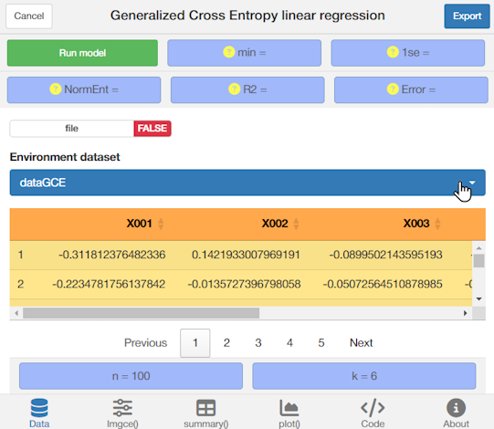

The parameters of `lmgce()` can be changed.

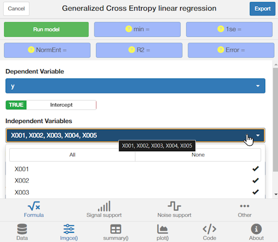

Several outputs can be visualized.

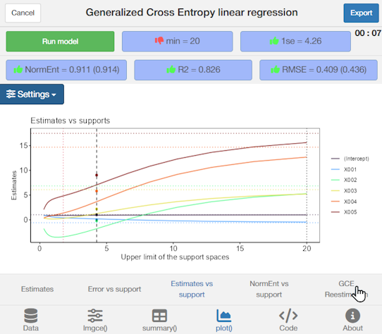

The expression for `lmgce()` can be exported.

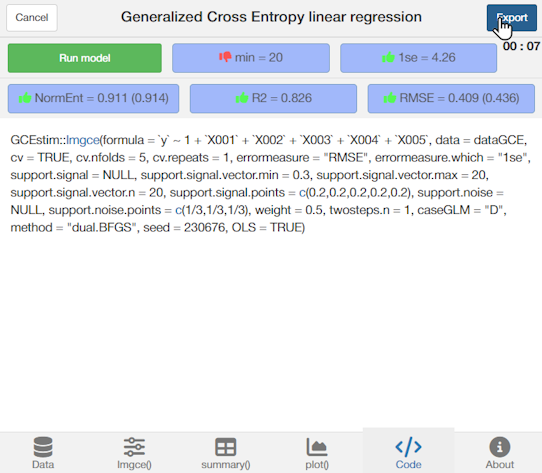

## cv.lmgce()

`lmgce()` allows for the evaluation of several support spaces and, given a certain criterion, selects one of them. But GCE estimation is also sensitive to the number of points of the signal and noise support spaces and to the weight that each of the spaces has in the loss function. `cv.lmgce()` tests the combination of these parameters.

```r
res.cv.lmgce <-
  cv.lmgce(
    y ~ X001 + X002 + X003 + X004,
    data = dataThesis,
    support.signal.points = c(3, 5, 7),
    support.noise.points = c(3, 5, 7),
    weight = c(0.1, 0.5, 0.9))
```

```r
res.cv.lmgce
```

```
#>
#> Call:
#> NULL
#>
#>
#> Best combination:
#> 5 points for the signal support; 7 points for the noise support; a weight of 0.1 for the noise support.
#>
#> Coefficients:
#> (Intercept)         X001         X002         X003         X004
#>     -3.7180       0.5083     -14.0683     -12.0299      -4.6681
```

It returns CV-errors, convergence of the optimization algorithm (0 means that convergence was obtained) and time.

```r
res.cv.lmgce$results[order(res.cv.lmgce$results$error.measure.cv.mean),][1:10,-6]
```

```
#>    support.signal.points support.noise.points weight error.measure
#> 8                      5                    7    0.1      1.005753
#> 4                      3                    5    0.1      1.014175
#> 1                      3                    3    0.1      1.017924
#> 5                      5                    5    0.1      1.018902
#> 9                      7                    7    0.1      1.019524
#> 2                      5                    3    0.1      1.020289
#> 7                      3                    7    0.1      1.029128
#> 18                     7                    7    0.5      1.029072
#> 6                      7                    5    0.1      1.035479
#> 3                      7                    3    0.1      1.036940
#>    error.measure.cv.mean convergence     time
#> 8              0.9699387           0 8.786073
#> 4              0.9778044           0 8.073933
#> 1              0.9813602           0 7.877780
#> 5              0.9822721           0 8.322070
#> 9              0.9828507           0 8.528754
#> 2              0.9836312           0 8.033961
#> 7              0.9919176           0 8.597163
#> 18             0.9979500           0 7.475526
#> 6              0.9981236           0 8.189654
#> 3              0.9995922           0 8.289415
```

The model with the combination that produces the lowest CV-error is kept.

```r
summary(res.cv.lmgce$best)
```

```
#>
#> Call:
#> cv.lmgce(formula = y ~ X001 + X002 + X003 + X004, data = dataThesis,
#>     support.signal.points = c(3, 5, 7), support.noise.points = c(3,
#>         5, 7), weight = c(0.1, 0.5, 0.9))
#>
#> Residuals:
#>     Min      1Q  Median      3Q     Max
#> -2.7959 -0.9089 -0.2023  0.2463  1.7122
#>
#> Coefficients:
#>               Estimate Std. Deviation z value Pr(>|t|)
#> (Intercept) -3.718e+00      6.790e-06 -547568   <2e-16 ***
#> X001         5.083e-01      7.140e-04     712   <2e-16 ***
#> X002        -1.407e+01      8.357e-04  -16835   <2e-16 ***
#> X003        -1.203e+01      5.008e-03   -2402   <2e-16 ***
#> X004        -4.668e+00      2.709e-03   -1723   <2e-16 ***
#> ---
#> Signif. codes:  0 '***' 0.001 '**' 0.01 '*' 0.05 '.' 0.1 ' ' 1
#>
#> Normalized Entropy:
#>              NormEnt   SupportLL  SupportUL
#> (Intercept) 0.864389   -8.155165   8.155165
#> X001        0.999966  -68.557748  68.557748
#> X002        0.993318 -135.817063 135.817063
#> X003        0.998443 -240.370090 240.370090
#> X004        0.999424 -153.350260 153.350260
#>
#> Residual standard error: 1.041 on 70 degrees of freedom
#> Chosen Upper Limit for Standardized Supports: 6.623, Chosen Error: 1se
#> Multiple R-squared: 0.8074, Adjusted R-squared: 0.7964
#> NormEnt: 0.9711, CV-NormEnt: 0.9711 (9.783e-05)
#> RMSE: 1.006, CV-RMSE: 0.9699 (0.2987)
```

Using `plot` we obtain

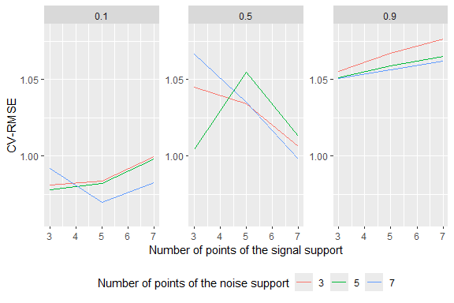

```r
plot(res.cv.lmgce, which = 1, ncol = 3)$p1 + ggplot2::ylim(0.96, 1.08)
```

## tsbootgce()

Consider the time series in the `ts` object `moz_ts`.

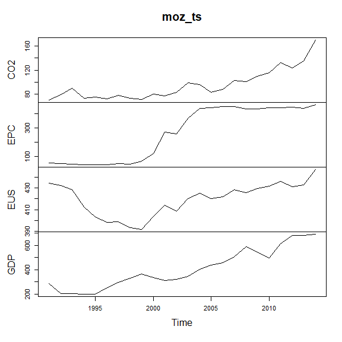

```r
plot(moz_ts)
```

Let:

- $CO2_t$ be the emissions of $CO_2$ at time $t$;
- $EPC_{t-1}$ be the energy per capita at time $t-1$;
- $EUS_{t-2}$ be the energy use at time $t-2$.
- $GDP_{t}$ be the gross domestic product at time $t$;

Using the function `tsbootgce()` and setting:

- `formula = CO2 ~ 1 + L(EPC, 1) + L(EUS, 2) + L(GDP, 0)`
- `data = moz_ts`

the desired model is computed. `formula` allows additional functions available in R package dynlm).

```r
res.tsbootgce <-
  tsbootgce(
    formula = CO2 ~ 1 + L(EPC, 1) + L(EUS, 2) + L(GDP, 0),
    data = moz_ts
    )
```

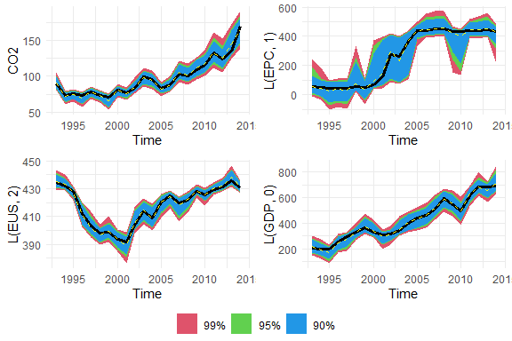

```r
plot(res.tsbootgce, which = 1)$p1
```

A concise summary of the result can be obtained simply by typing,

```r
res.tsbootgce
```

```
#>
#> Call:
#> tsbootgce(formula = CO2 ~ 1 + L(EPC, 1) + L(EUS, 2) + L(GDP,
#>     0), data = moz_ts)
#>
#> Coefficients:
#>            (Intercept)  L(EPC, 1)   L(EUS, 2)   L(GDP, 0)
#> tsbootgce   -33.92155      0.02398     0.26146     0.03765
#> MEbootOLS  -180.52201     -0.01012     0.54850     0.12507
#> lmgce       -30.04711      0.02333     0.25202     0.03879
#> lm         -176.86713     -0.02947     0.53022     0.14320
```

The `tsbootgce` coefficients displayed by default are `coef.method = "mode"`.

```r
coef(res.tsbootgce)
```

```
#>  (Intercept)    L(EPC, 1)    L(EUS, 2)    L(GDP, 0)
#> -33.92154689   0.02398360   0.26145975   0.03765138
```

and the $95\%$ highest density regions are

```r
confint(res.tsbootgce)
```

```
#>                     2.5%        97.5%
#> (Intercept) -49.28332851 -18.59101696
#> L(EPC, 1)     0.01930974   0.02898740
#> L(EUS, 2)     0.22748595   0.29642204
#> L(GDP, 0)     0.03324949   0.04209782
```

The empirical distribution, confidence intervals and measure of central tendency of each estimate can be visualized by typing

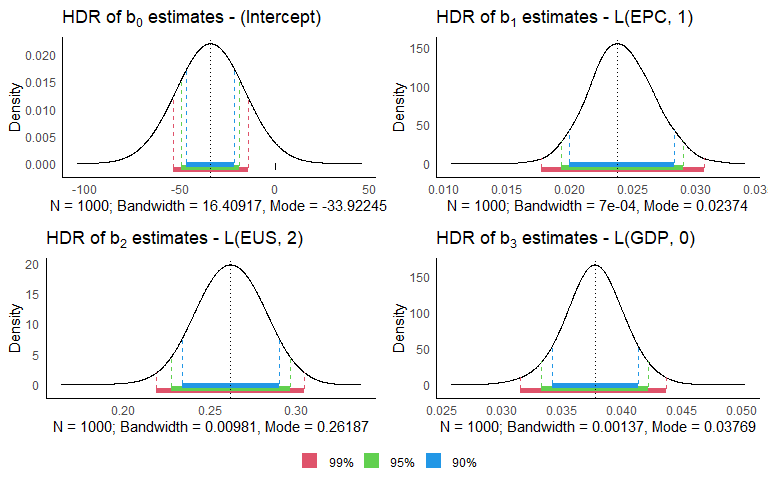

```r
plot(res.tsbootgce,
     which = 2,
     ci.levels = c(0.90, 0.95, 0.99),
     ci.method = c("hdr" #,"basic" #,"percentile"
       ))$p2
```

## neagging()

The estimates obtained in each bootstrap repetition have a normalized entropy associated that can be used as a weight for an aggregation procedure named neagging.

### lmgce object

`lmgce` objects keep the bootstrap result in `object$results$bootstrap` when the argument `boot.B` is greater or equal to `10`. In the case of existence of these results we can call the function `neagging` setting only the `object` parameter.

```r
res.neagging.lmgce <- neagging(res.lmgce.v02)
```

The trace of the in sample error can be obtained with `plot`.

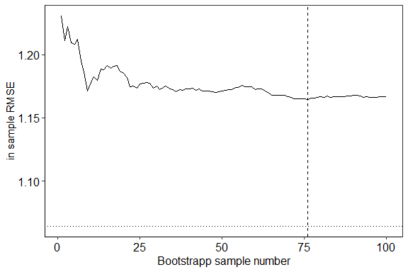

```r
plot(res.neagging.lmgce)
```

The dotted horizontal line represents the in sample error of the `lmgce` model. The neagging minimum in sample error, represented by the vertical dashed line, was obtained aggregating 76 models

```r
which.min(res.neagging.lmgce$error)[[1]]
```

```
#> [1] 76
```

The trace of the estimates can also be visualized with `plot`, where the dotted horizontal lines represent the estimates from the `lmgce` model.

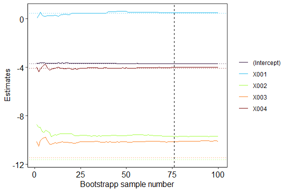

```r
plot(res.neagging.lmgce, which = 2)
```

The estimated coefficients that produce the lowest in sample error are $\widehat{\boldsymbol{\beta}}^{neagging}=$ (-3.701, 0.485, -9.72, -10.134, -4.005).

```r
coef(res.neagging.lmgce)
```

```
#> (Intercept)        X001        X002        X003        X004
#>  -3.7008289   0.4847928  -9.7204382 -10.1339057  -4.0050171
```

```r
coef(res.neagging.lmgce, which = ncol(res.neagging.lmgce$matrix))
```

```
#> (Intercept)        X001        X002        X003        X004
#>  -3.6990340   0.5021118  -9.7069818 -10.0843435  -3.9856238
```

### tsbootgce object

`tsbootgce` objects always keep the bootstrap result in `object$results$bootstrap` so we can call the function `neagging` setting only the `object` parameter.

```r
res.neagging.tsbootgce <- neagging(res.tsbootgce)
```

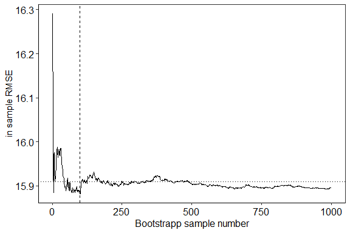

```r
plot(res.neagging.tsbootgce)
```

In this case the in sample error is lower in the neagging approach.

## Acknowledgements

This work was supported by Fundação para a Ciência e Tecnologia (FCT) through CIDMA and projects https://doi.org/10.54499/UIDB/04106/2020 and https://doi.org/10.54499/UIDP/04106/2020.